# Spells and Spreadsheets: Decoding the Wizarding World with Data Science

Viviana Lara, Justin Cline

## Introduction

In the realm of fantasy literature and cinema, few franchises have captured the imagination quite like Harry Potter. But beyond the spellbinding narratives lies a wealth of data waiting to be explored. Our analysis aims to uncover the hidden patterns and insights within the Harry Potter movie series, using a comprehensive dataset that spans characters, dialogue, spells, and movie statistics.

The central question we seek to answer is: How do the various elements of the Harry Potter universe interact and evolve throughout the series? To address this, we’ll be diving into multiple CSV files, including:

- **Chapters.csv:** Contains information about movie chapters, including character IDs, chapter names, movie IDs, and chapter numbers within each movie script.
- **Characters.csv:** Provides detailed information about characters, including their species, gender, Hogwarts house, patronus, and wand properties.
- **Dialogue.csv:** Contains every line of dialogue from the movie scripts, linked to characters, chapters, and locations.
- **Movies.csv:** Offers production details for each movie, including title, release year, runtime, budget, and box office performance.
- **Places.csv:** Lists various locations in the Harry Potter universe, categorized by type.
- **Spells.csv:** Details the various spells used in the series, including their incantations, effects, and associated light.

By analyzing this rich dataset, we aim to reveal trends in character development, explore the complexity of magic over time, and even draw connections between the fictional world and real-world factors like movie budgets and audience reception. Whether you’re a die-hard fan or a data enthusiast, this analysis promises to shed new light on the intricate tapestry of the wizarding world, all through the lens of data science.

# About the Dataset

```
## Rows: 61
## Columns: 5
## $ Spell.ID    <int> 1, 2, 3, 4, 5, 6, 7, 8, 9, 10, 11, 12, 13, 14, 15, 16, 17,…
## $ Incantation <chr> "Accio", "Aguamenti", "Alarte Ascendare", "Alohomora", "Ar…
## $ Spell.Name  <chr> "Summoning Charm", "Water-Making Spell", "Launch an object…
## $ Effect      <chr> "Summons an object", "Conjures water", "Rockets target upw…
## $ Light       <chr> "", "Icy Blue", "Red", "Blue", "Blue", "", "Green", "", "B…
```

```
## Rows: 74
## Columns: 3
## $ Place.ID       <int> 1, 2, 3, 4, 5, 6, 7, 8, 9, 10, 11, 12, 13, 14, 15, 16, …
## $ Place.Name     <chr> "Flourish & Blotts", "Gringotts Wizarding Bank", "Knock…
## $ Place.Category <chr> "Diagon Alley", "Diagon Alley", "Diagon Alley", "Diagon…
```

```
## Rows: 7,444
## Columns: 5
## $ Dialogue.ID  <int> 1, 2, 3, 4, 5, 6, 7, 8, 9, 10, 11, 12, 13, 14, 15, 16, 17…
## $ Chapter.ID   <int> 1, 1, 1, 1, 1, 1, 1, 1, 1, 1, 1, 1, 1, 1, 1, 1, 2, 2, 2, …
## $ Place.ID     <int> 8, 8, 8, 8, 8, 8, 8, 8, 8, 8, 8, 8, 8, 8, 8, 8, 8, 8, 8, …
## $ Character.ID <int> 4, 7, 4, 7, 4, 7, 4, 5, 4, 5, 7, 4, 7, 4, 4, 4, 32, 31, 3…
## $ Dialogue     <chr> "I should have known that you would be here...Professor M…
```

# House Dynamics

This analysis explores the characteristics and demographics of different Hogwarts houses and magical schools using the Characters dataset. We examine several key variables including:

- House affiliation (Gryffindor, Slytherin, Ravenclaw, Hufflepuff, Beauxbatons, Durmstrang)
- Gender distribution within houses
- Blood status diversity (Pure-blood, Half-blood, Muggle-born, etc.)
- Physical characteristics (Hair color, Eye color)
- Magical abilities (Patronus forms)

### Distribution of Characters Across Hogwarts Houses

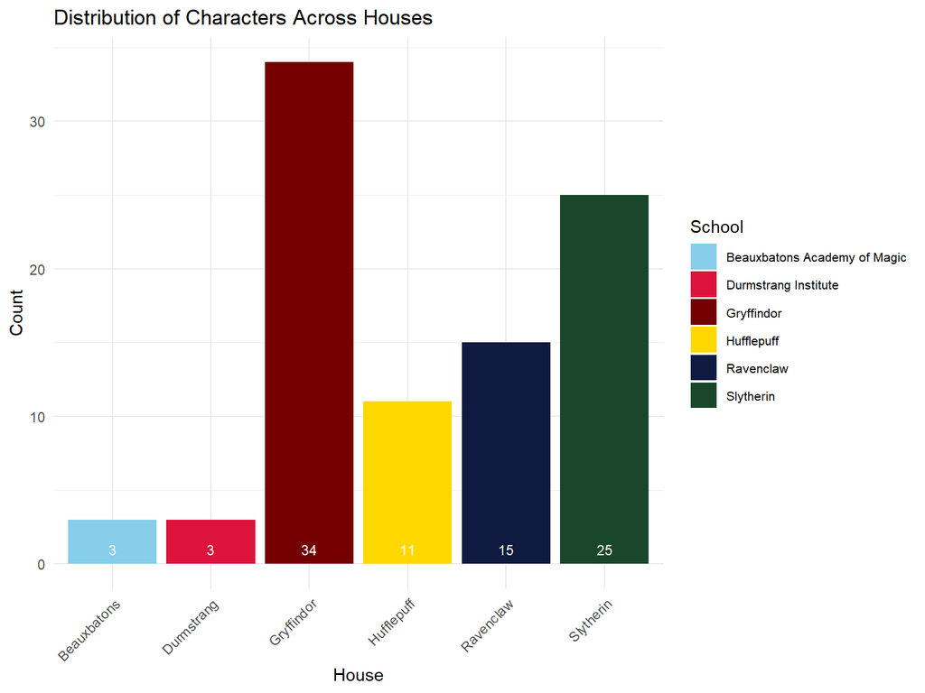

### Gender Distribution

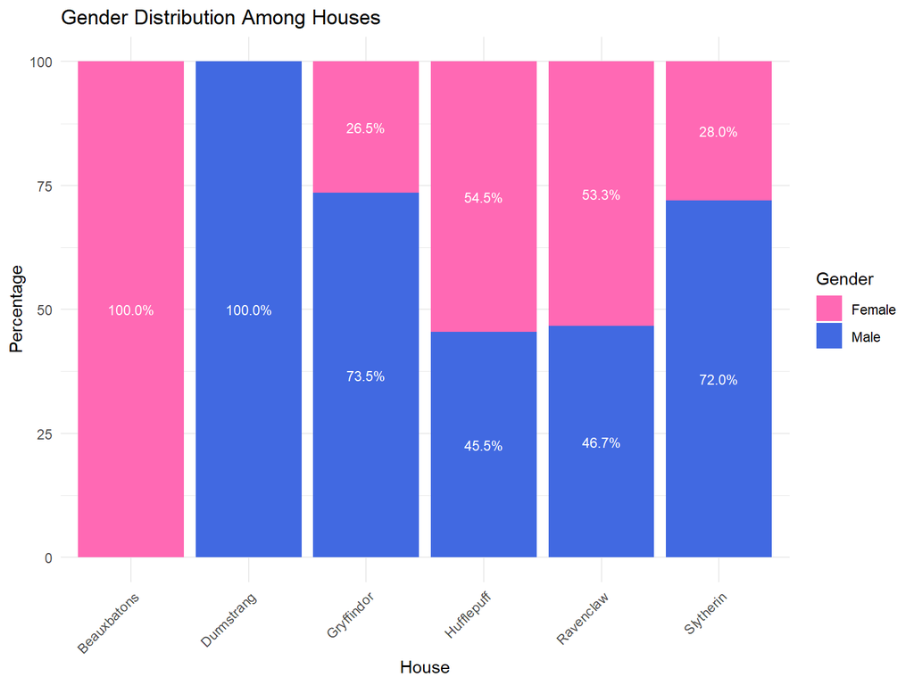

### Blood Status Diversity

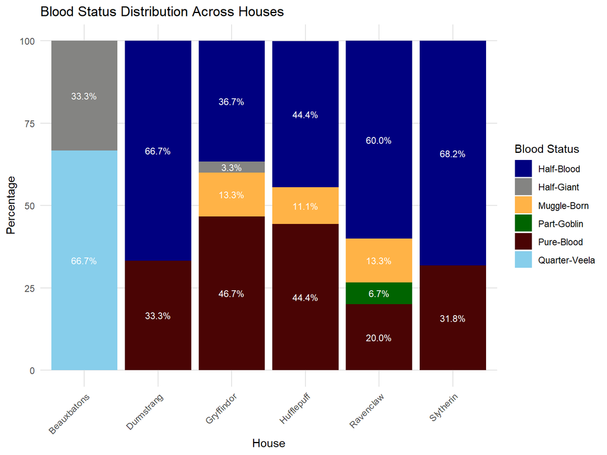

### Physical Characteristics

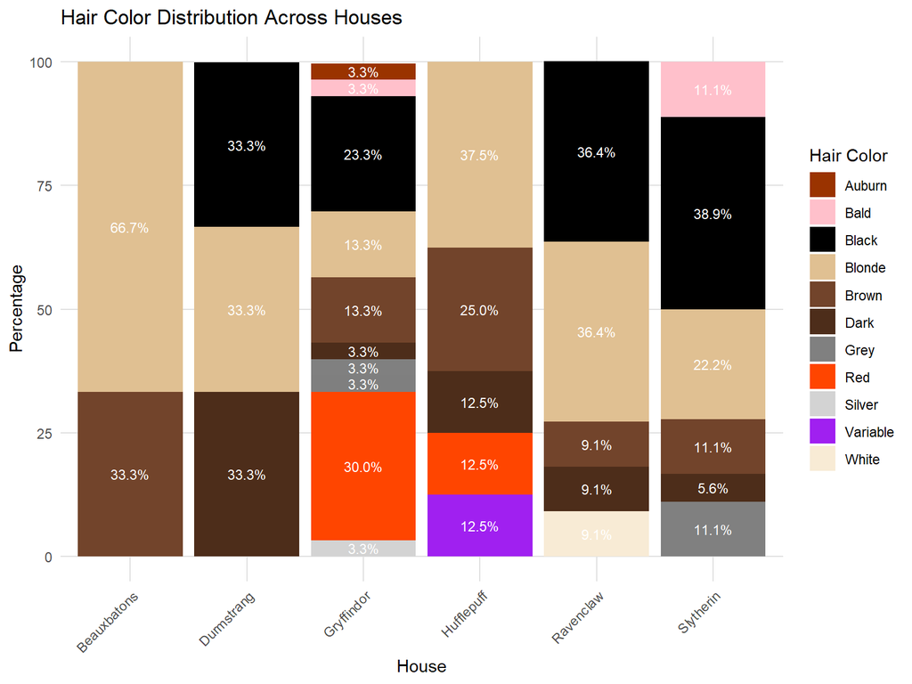

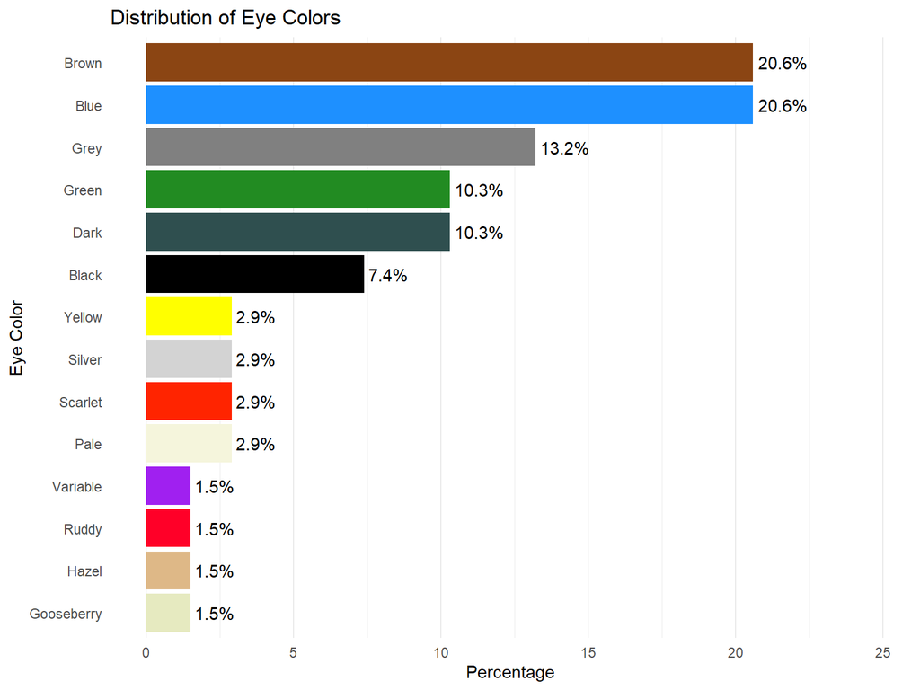

### Patronus Forms

Top 10 Most Common Patronus Forms

| Patronus Form | Number of Characters | Percentage |
| --- | --- | --- |
| Non-corporeal | 29 | 51.8 |
| None | 7 | 12.5 |
| Cat | 2 | 3.6 |
| Doe | 2 | 3.6 |
| Stag | 2 | 3.6 |
| Boar | 1 | 1.8 |
| Fox | 1 | 1.8 |
| Goat | 1 | 1.8 |
| Hare | 1 | 1.8 |
| Horse | 1 | 1.8 |

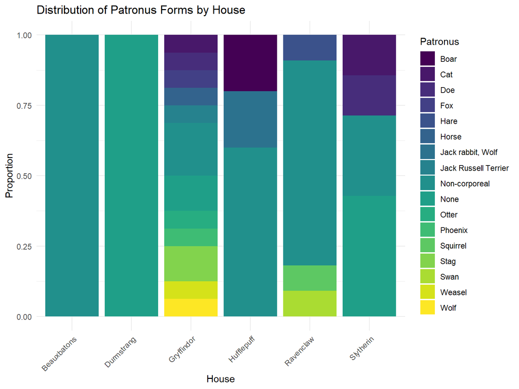

# Dialogue Analysis

To analyze dialogue patterns across the Harry Potter movie series, we examined the following datasets:

- Dialogue.csv: Contains character dialogue lines with Character.ID and Chapter.ID
- Characters.csv: Provides character details including House affiliation
- Chapters.csv: Links dialogues to specific movie chapters
- Movies.csv: Contains movie titles and chronological information

Key variables analyzed include:

- Individual dialogue lines and their frequency
- Distribution of dialogue across Houses
- Speaking patterns of main characters (Golden Trio)
- Common words and phrases used throughout the series

### Frequently Used Words

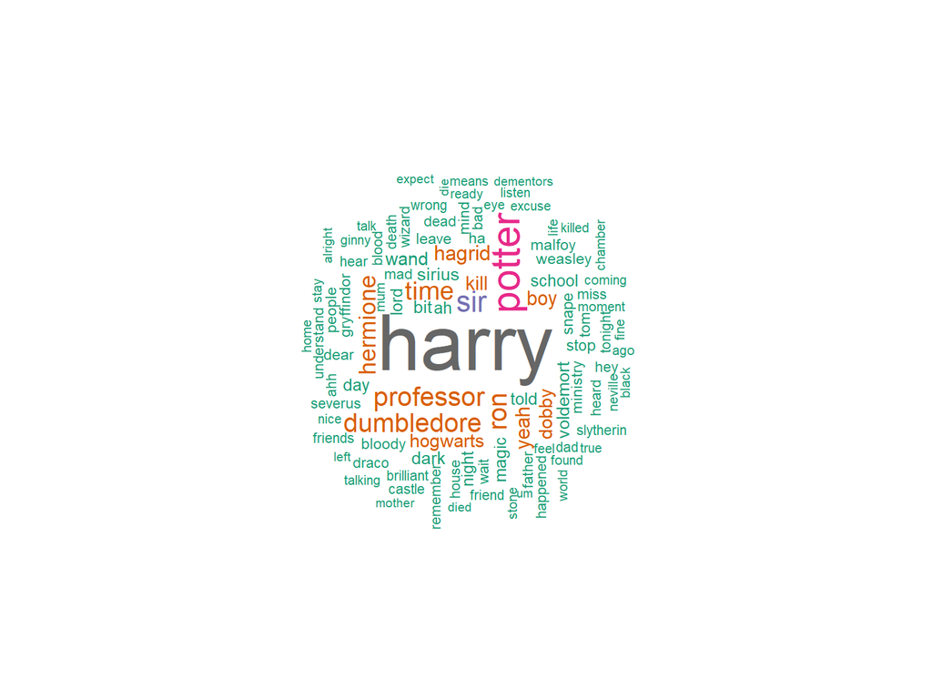

| Word | Word Statistics Frequency | Word Statistics Percentage |
| --- | --- | --- |
| harry | 690 | 22.38 |
| potter | 295 | 9.57 |
| sir | 198 | 6.42 |
| professor | 172 | 5.58 |
| dumbledore | 164 | 5.32 |
| ron | 164 | 5.32 |
| time | 159 | 5.16 |
| hermione | 139 | 4.51 |
| hagrid | 118 | 3.83 |
| yeah | 107 | 3.47 |
| boy | 103 | 3.34 |
| kill | 101 | 3.28 |
| dobby | 94 | 3.05 |
| hogwarts | 91 | 2.95 |
| wand | 84 | 2.72 |
| sirius | 83 | 2.69 |
| bit | 82 | 2.66 |
| voldemort | 82 | 2.66 |
| dark | 80 | 2.59 |
| day | 77 | 2.50 |

### Locations with Most Dialogue

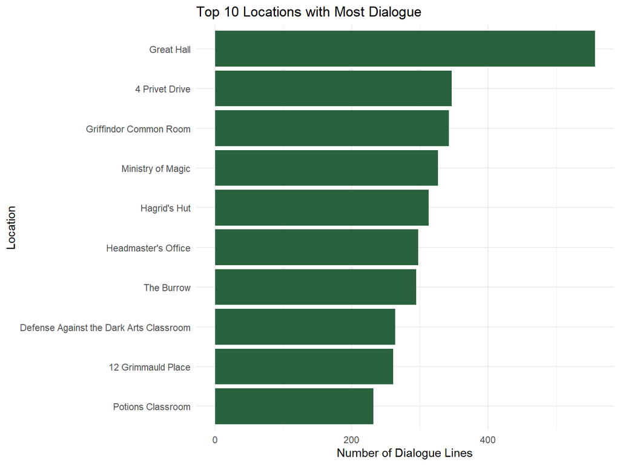

### Representation of Different Houses in Dialogue Across the Movie Series

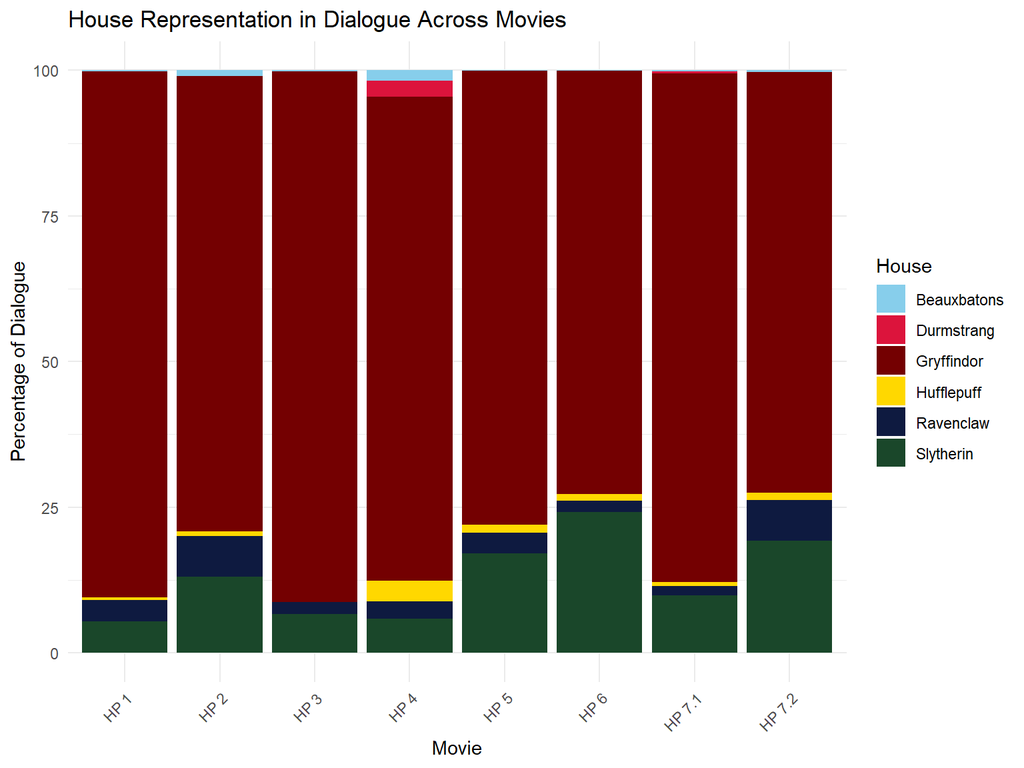

Overall House Representation in Dialogue

| House | Total Lines of Dialogue | Percentage of All Dialogue |
| --- | --- | --- |
| Gryffindor | 5394 | 81.3 |
| Slytherin | 883 | 13.3 |
| Ravenclaw | 239 | 3.6 |
| Hufflepuff | 73 | 1.1 |
| Beauxbatons | 28 | 0.4 |
| Durmstrang | 20 | 0.3 |

### Golden Trio Dialogue Distribution

[figure not shown]

# Spell Analysis

To find spell usage by each character and house we utilize a function to search through every line of dialogue searching for occurrences of spell incantations and then record the which character used the spell and what spell they used.

To analyze spell usage throughout the Harry Potter movies we examined the following datasets:

- Dialogue.csv: Contains each line of dialogue and who said it
- Spells.csv: Contains the spell incantations

Key Variables include:

- Individual dialogue lines and the incantations they contain
- Character names
- House names
- Incantations (e.g. Sectum Sempra, Expelliarmus)

### Spell Finder Function

```r
SpellFinder <- function(dialogueDF, spellsDF) {
  #Initializes up the matches data frame to hold the
  #line of dialogue and spell being used in that line of dialogue.
  Matches <- data.frame(
    Dialogue = character(),
    Spell = character()
  )
  #for each spell in the Spells data frame we identify which lines of
  #dialogue contain that spell and add those lines of dialogue to the MatchingLines vector.
  for (spell in spellsDF$Incantation) {
    MatchingLines <- dialogueDF$Dialogue[str_detect(
      dialogueDF$Dialogue,spell)]

#Stores the vector MatchingLines in a temporary data
#frame and Labels each dialogue with the spell found in them from this iteration of the loop.
    MatchesTemp <- data.frame(
      Dialogue = MatchingLines,
      Spell = rep(spell, length(MatchingLines))
    )
#Once we have a temporary data frame with each of the
#lines of dialogue and have labeled them by the
#spell used we can add the dialogues with this
#iterations spells to a final data frame which will hold
#all lines of dialogue with a spell from all iterations at the end of the loop
      Matches <- rbind(Matches,MatchesTemp)
      }

  return(Matches)
}
```

### Spell Usage by the golden trio

[figure not shown]

### How many times each spell has been used as the movies progress

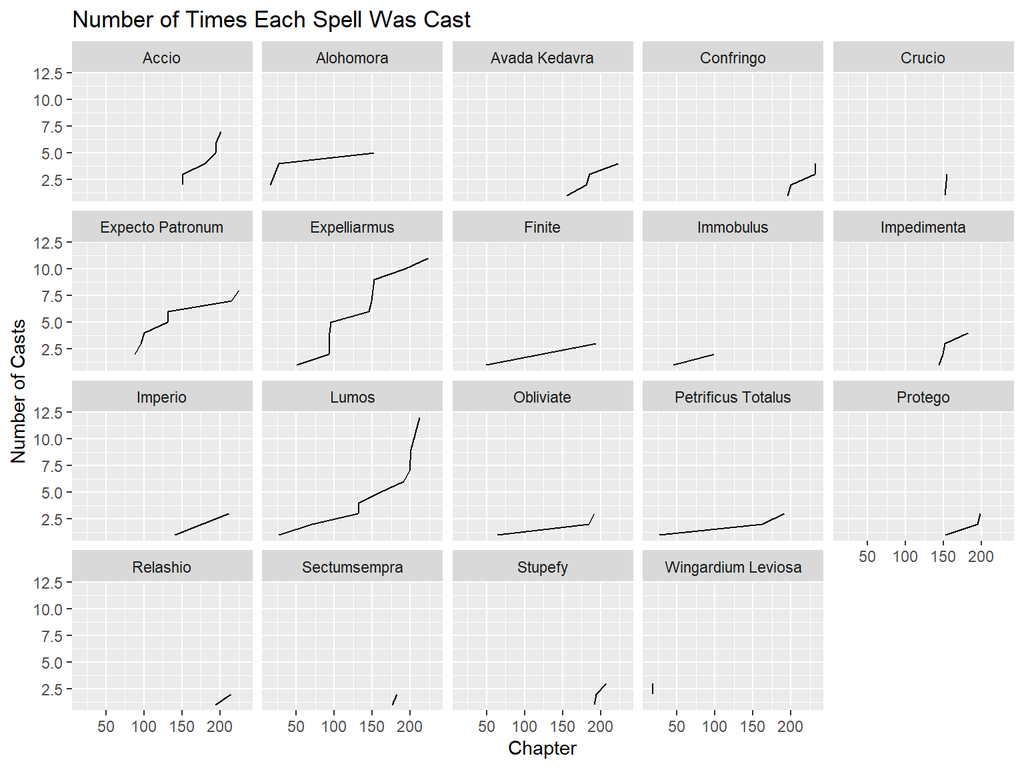

### Which spells are used most frequently by each character

[figure not shown]

### Which spells are used most frequently by each house

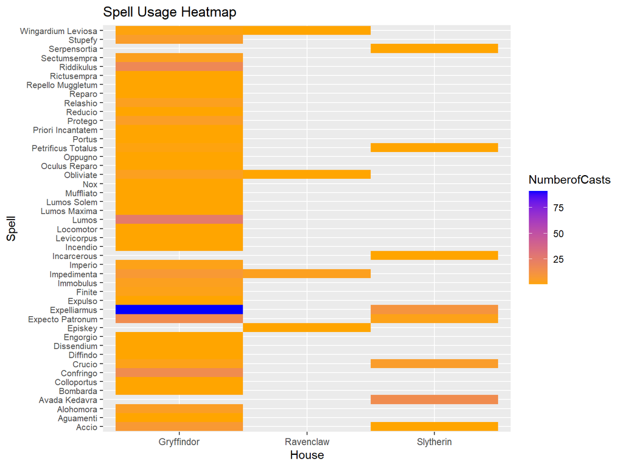

### Which spells are most frequently used by each gender

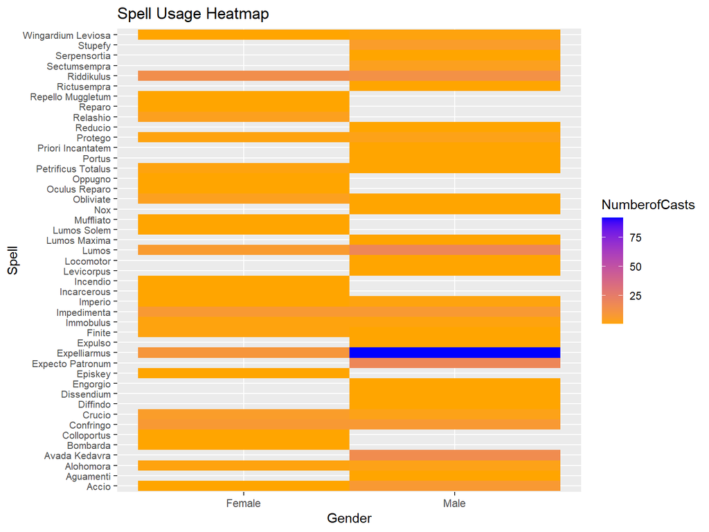

# Wand Analysis

To analyze wand characteristics and their distribution across the Harry Potter universe, we examined the following datasets:

- Characters.csv: Contains wand details including wood type, core, and length

Key variables analyzed include:

- Wand length (measured in inches)
- Wand wood type (e.g., Holly, Oak, Vine)
- Wand core material (e.g., Phoenix feather, Dragon heartstring)
- Character house affiliation

### Distribution of Wands Across Houses

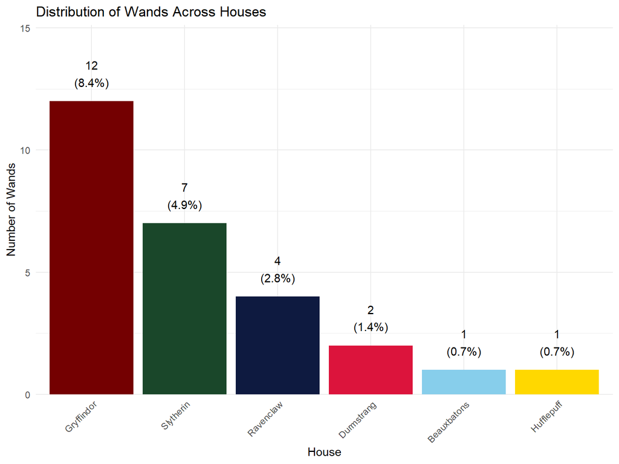

### Wand Length Distribution by Wood Type and Core

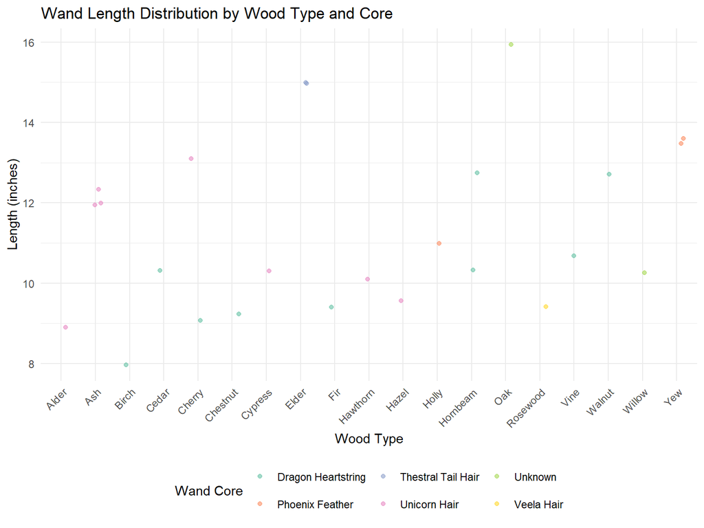